# TCGA Plot Caller Comparisons

C. Savonen for ALSF CCDL

2019

Purpose: Why are TCGA and PBTA data so different?

#### Usage

To run this from the command line, use:

```
Rscript -e "rmarkdown::render('analyses/snv-callers/compare_snv_callers_plots-tcga.Rmd',
                              clean = TRUE)"
```

*This assumes you are in the top directory of the repository.*

## Setup

#### Packages and functions

Read in set up script.

```r
# Magrittr pipe
`%>%` <- dplyr::`%>%`

source(file.path("..", "snv-callers", "util", "tmb_functions.R"))
source(file.path("..", "chromosomal-instability", "util", "chr-break-plot.R"))
source(file.path("..", "chromosomal-instability", "util", "circos-plots.R"))
```

Declare directory paths.

```r
scratch_dir <- file.path("..", "..", "scratch")
data_dir <- file.path("..", "..", "data")
plots_dir <- file.path("plots", "tcga-vs-pbta-plots")

if (!dir.exists(plots_dir)) {
  dir.create(plots_dir)
}
```

### Special functions

Function for setting up PBTA data from the database.

```r
set_up_pbta <- function(data.name) {
  # Start up connection
  con <- DBI::dbConnect(RSQLite::SQLite(),
                        file.path(scratch_dir, "v11_snv_db.sqlite"))

  # Connect to SQL
  df <- dplyr::tbl(con, data.name) %>%
    dplyr::select(join_cols, "VAF") %>%
    as.data.frame() %>%
    dplyr::inner_join(
    pbta_metadata %>%
      dplyr::select(Tumor_Sample_Barcode = Kids_First_Biospecimen_ID,
                    experimental_strategy, short_histology))

  return(df)
}
```

Function for setting up TCGA data from the database.

```r
set_up_tcga <- function(data.name) {
    # Start up connection
  con <- DBI::dbConnect(RSQLite::SQLite(), file.path(scratch_dir, "tcga_snv_db.sqlite"))

  # Connect to SQL
  df <- dplyr::tbl(con, data.name) %>%
    dplyr::select(join_cols) %>%
    as.data.frame() %>%
    # Shorten the Tumor_Sample_Barcode so it matches
    dplyr::mutate(Tumor_Sample_Barcode = substr(Tumor_Sample_Barcode, 0, 12)) %>%
    dplyr::inner_join(tcga_metadata %>% dplyr::select(Tumor_Sample_Barcode, short_histology, experimental_strategy))

  return(df)
}
```

Function for making a combined CDF plot for TMB.

```r
tmb_cdf_plot <- function(tmb_df, plot_title) {
  cdf_plot <- tmb_df %>%
    as.data.frame() %>%
    dplyr::mutate(short_histology = tools::toTitleCase(short_histology)) %>%
    # Only plot histologies groups with more than `min_samples` number of samples
    dplyr::group_by(short_histology, add = TRUE) %>%
    # Only keep groups with this amount of samples
    dplyr::filter(dplyr::n() > 5) %>%
    # Calculate histology group mean
    dplyr::mutate(
      hist_mean = mean(tmb),
      hist_rank = rank(tmb, ties.method = "first") / dplyr::n(),
      sample_size = paste0("n = ", dplyr::n())
    ) %>%
    dplyr::ungroup() %>%
    dplyr::mutate(short_histology = reorder(short_histology, hist_mean)) %>%
    # Now we will plot these as cummulative distribution plots
    ggplot2::ggplot(ggplot2::aes(
      x = hist_rank,
      y = tmb,
      color = datasets
    )) +
    ggplot2::geom_point() +
    # Add summary line for mean
    ggplot2::geom_segment(x = 0, xend = 1, color = "grey",
                          ggplot2::aes(y = hist_mean, yend = hist_mean)) +
    # Separate by histology
    ggplot2::facet_wrap(~ short_histology + sample_size, nrow = 1, strip.position = "bottom") +
    ggplot2::theme_classic() +
    ggplot2::xlab("") +
    ggplot2::ylab("TMB") +
    # Transform to log10 make non-log y-axis labels
    ggplot2::scale_y_continuous(trans = "log1p", breaks = c(0, 1, 3, 10, 30)) +
    ggplot2::scale_x_continuous(limits = c(-0.2, 1.2), breaks = c()) +
    # Making it pretty
    ggplot2::theme(legend.position = "none") +
    ggplot2::theme(
      axis.text.x = ggplot2::element_blank(),
      axis.ticks.x = ggplot2::element_blank(),
      strip.placement = "outside",
      strip.text = ggplot2::element_text(size = 10, angle = 90, hjust = 1),
      strip.background = ggplot2::element_rect(fill = NA, color = NA)
    ) +
    ggplot2::ggtitle(plot_title)

  ggplot2::ggsave(filename = file.path(plots_dir, paste0(plot_title, ".png")), plot = cdf_plot, width = 10, height = 7.5)

  cdf_plot
}
```

Function for comparing the sequence overlap of two GenomicRanges objects.

```r
bed_overlap <- function(bed_granges_1,
                        bed_granges_2,
                        name_1,
                        name_2,
                        plot_name) {
  # Find intersection
  overlaps <- GenomicRanges::intersect(bed_granges_1, bed_granges_2)

  # Percent of TCGA Target region covered by overlap
  sum(overlaps@ranges@width) / sum(bed_granges_2@ranges@width)

  # Percent of PBTA Target region covered by overlap
  sum(bed_granges_1@ranges@width)

  # Make filename to save plot as
  plot.file <- file.path(plots_dir, paste0(plot_name, ".png"))

  # Make the Venn diagram
  grid::grid.newpage();
  venn.plot <- VennDiagram::draw.pairwise.venn(
    area1 = sum(bed_granges_1@ranges@width),
    area2 = sum(bed_granges_2@ranges@width),
    cross.area = sum(overlaps@ranges@width),
    category = c(name_1, name_2),
    fill = c("#F8766D", "#00BFC4"),
    cex = 2,
    cat.cex = 1.5,
    #cat.dist = c(-0.05, -0.05),
    #cat.pos = c(170, 65),
    ext.pos = 0,
    ext.dist = -0.01,
    ext.length = .8,
    ext.line.lwd = 2,
    ext.line.lty = "dashed",
    margin = 0.1);
  grid::grid.draw(venn.plot)

  png(plot.file);
  grid::grid.draw(venn.plot);
  dev.off()

  cat(" Ratio of", name_1, "overlapped:",
     sum(overlaps@ranges@width)/sum(bed_granges_1@ranges@width), "\n",
     "Ratio of", name_2, "overlapped:",
     sum(overlaps@ranges@width)/sum(bed_granges_2@ranges@width), "\n"
    )
}
```

Read in the metadata.

```r
pbta_metadata <- readr::read_tsv(file.path(data_dir, "pbta-histologies.tsv"))
```

[output not shown]

```r
tcga_metadata <- readr::read_tsv(file.path(data_dir, "pbta-tcga-manifest.tsv")) %>%
    dplyr::mutate(experimental_strategy = "WXS", # This field doesn't exist for this data, but all is WXS
                  short_histology = Primary_diagnosis) # This field is named differently
```

## Connect to databases

Note what columns we will join by.

```r
join_cols = c("Chromosome",
              "Start_Position",
              "End_Position",
              "Reference_Allele",
              "Allele",
              "Tumor_Sample_Barcode",
              "Variant_Classification",
              "t_depth",
              "t_ref_count",
              "t_alt_count",
              "n_depth",
              "n_ref_count",
              "n_alt_count",
              "VAF")
```

Set up TCGA data.

```r
tcga_lancet <- set_up_tcga("lancet")
tcga_mutect <- set_up_tcga("mutect")
tcga_strelka <- set_up_tcga("strelka")
tcga_consensus <- set_up_tcga("consensus")
```

Set up PBTA data.

```r
pbta_lancet <- set_up_pbta("lancet")
pbta_mutect <- set_up_pbta("mutect")
```

Set up combined PBTA and TCGA data.frames.

```r
lancet <- dplyr::bind_rows(list(tcga = tcga_lancet,
                                pbta = pbta_lancet), .id = "dataset") %>%
  dplyr::mutate(dataset = as.factor(dataset))

mutect <- dplyr::bind_rows(list(tcga = tcga_mutect,
                                pbta = pbta_mutect), .id = "dataset") %>%
  dplyr::mutate(dataset = as.factor(dataset))

strelka <- dplyr::bind_rows(list(tcga = tcga_strelka,
                                pbta = pbta_strelka), .id = "dataset") %>%
  dplyr::mutate(dataset = as.factor(dataset))
```

## Is this a tumor sequencing depth problem for certain callers?

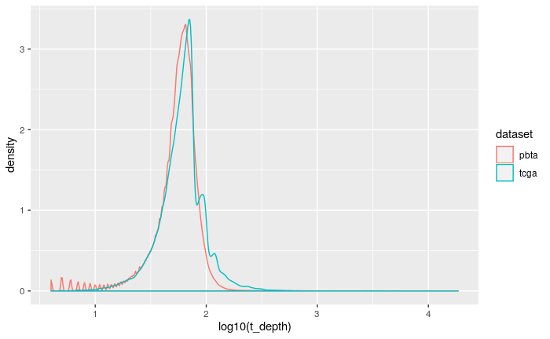

```r
lancet %>%
  ggplot2::ggplot(ggplot2::aes(x = log10(t_depth), color = dataset)) +
  ggplot2::geom_density()
```

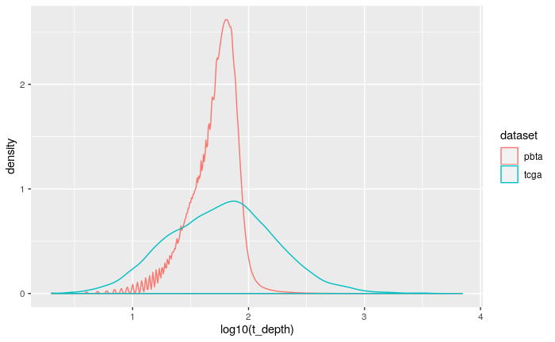

```r
mutect %>%
  ggplot2::ggplot(ggplot2::aes(x = log10(t_depth), color = dataset)) +
  ggplot2::geom_density()
```

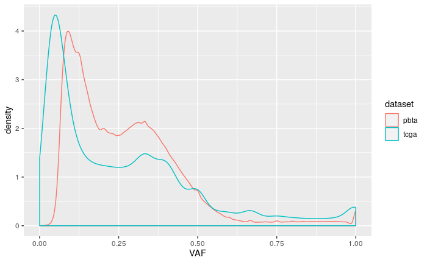

```r
strelka %>%
  ggplot2::ggplot(ggplot2::aes(x = VAF, color = dataset)) +
  ggplot2::geom_density()
```

## Is this a caller specific problem

Lancet only TMB:

```r
lancet_tmb <- dplyr::bind_rows(list(pbta = calculate_tmb(pbta_lancet,
  bed_wgs = file.path(data_dir, "intersect_cds_lancet_strelka_mutect_WGS.bed"),
  bed_wxs = file.path(scratch_dir, "intersect_cds_WXS.bed")
  ),
  tcga = calculate_tmb(tcga_lancet,
  bed_wgs = file.path(scratch_dir, "intersect_cds_lancet_strelka_mutect_WGS.bed"), # There's no TCGA WGS samples, this is just a place holder and won't be used.
  bed_wxs = file.path("ref_files", "hg38_liftover_genome_gencode.v19.basic.exome.bed")
  )), .id = "datasets")
```

```
Ratio of variants in this BED: 0.8891623
 Ratio of variants being filtered out: 0.1108377
Ratio of variants in this BED: 1.651031
 Ratio of variants being filtered out: -0.6510313
```

```
Unreplaced values treated as NA as .x is not compatible. Please specify replacements exhaustively or supply .defaultParsed with column specification:
Each of the 2 combined objects has sequence levels not in the other:
  - in 'x': chrX, chrY
  - in 'y': chr1_KI270766v1_alt, chr4_GL000008v2_random, chrUn_KI270742v1, chr1_KI270706v1_random, chr14_GL000009v2_random, chr7_KI270803v1_alt, chr15_KI270850v1_alt, chr17_KI270909v1_alt, chr19_KI270938v1_alt, chr22_KI270879v1_alt
  Make sure to always combine/compare objects based on the same reference
  genome (use suppressWarnings() to suppress this warning).
```

```
Ratio of variants in this BED: 2.253526
 Ratio of variants being filtered out: -1.253526
Ratio of variants in this BED: NaN
 Ratio of variants being filtered out: NaN
```

[figure not shown]

```r
tmb_cdf_plot(lancet_tmb, plot_title = "Lancet")
```

Mutect only TMB:

```r
mutect_tmb <- dplyr::bind_rows(list(pbta = calculate_tmb(pbta_mutect,
  bed_wgs = file.path(data_dir, "intersect_cds_lancet_strelka_mutect_WGS.bed"),
  bed_wxs = file.path(scratch_dir, "intersect_cds_WXS.bed")
  ),
  tcga = calculate_tmb(tcga_mutect,
  bed_wgs = file.path(scratch_dir, "intersect_cds_lancet_strelka_mutect_WGS.bed"),
  bed_wxs = file.path("ref_files", "hg38_liftover_genome_gencode.v19.basic.exome.bed")
  )), .id = "datasets")
```

```
Ratio of variants in this BED: 0.9629715
 Ratio of variants being filtered out: 0.03702852
Ratio of variants in this BED: 1.091582
 Ratio of variants being filtered out: -0.09158185
```

```
Unreplaced values treated as NA as .x is not compatible. Please specify replacements exhaustively or supply .defaultParsed with column specification:
Each of the 2 combined objects has sequence levels not in the other:
  - in 'x': chrX, chrY
  - in 'y': chr1_KI270766v1_alt, chr4_GL000008v2_random, chrUn_KI270742v1, chr1_KI270706v1_random, chr14_GL000009v2_random, chr7_KI270803v1_alt, chr15_KI270850v1_alt, chr17_KI270909v1_alt, chr19_KI270938v1_alt, chr22_KI270879v1_alt
  Make sure to always combine/compare objects based on the same reference
  genome (use suppressWarnings() to suppress this warning).
```

```
Ratio of variants in this BED: 1.520558
 Ratio of variants being filtered out: -0.5205582
Ratio of variants in this BED: NaN
 Ratio of variants being filtered out: NaN
```

[figure not shown]

```r
tmb_cdf_plot(mutect_tmb, plot_title = "Mutect2")
```

Strelka only TMB:

```r
strelka_tmb <- dplyr::bind_rows(list(pbta = calculate_tmb(pbta_strelka,
  bed_wgs = file.path(data_dir, "intersect_cds_lancet_strelka_mutect_WGS.bed"),
  bed_wxs = file.path(scratch_dir, "intersect_cds_WXS.bed")
  ),
  tcga = calculate_tmb(tcga_strelka,
  bed_wgs = file.path(scratch_dir, "intersect_cds_lancet_strelka_mutect_WGS.bed"),
  bed_wxs = file.path("ref_files", "hg38_liftover_genome_gencode.v19.basic.exome.bed")
  )), .id = "datasets")
```

```
Ratio of variants in this BED: 0.685885
 Ratio of variants being filtered out: 0.314115
Ratio of variants in this BED: 1.110021
 Ratio of variants being filtered out: -0.1100208
```

```
Unreplaced values treated as NA as .x is not compatible. Please specify replacements exhaustively or supply .defaultParsed with column specification:
Each of the 2 combined objects has sequence levels not in the other:
  - in 'x': chrX, chrY
  - in 'y': chr1_KI270766v1_alt, chr4_GL000008v2_random, chrUn_KI270742v1, chr1_KI270706v1_random, chr14_GL000009v2_random, chr7_KI270803v1_alt, chr15_KI270850v1_alt, chr17_KI270909v1_alt, chr19_KI270938v1_alt, chr22_KI270879v1_alt
  Make sure to always combine/compare objects based on the same reference
  genome (use suppressWarnings() to suppress this warning).
```

```
Ratio of variants in this BED: 1.514101
 Ratio of variants being filtered out: -0.5141007
Ratio of variants in this BED: NaN
 Ratio of variants being filtered out: NaN
```

[figure not shown]

```r
tmb_cdf_plot(strelka_tmb, plot_title = "Strelka2")
```

Consensus TMB:

```r
consensus_tmb <- dplyr::bind_rows(list(pbta = calculate_tmb(pbta_consensus,
  bed_wgs = file.path(data_dir, "intersect_cds_lancet_strelka_mutect_WGS.bed"),
  bed_wxs = file.path(scratch_dir, "intersect_cds_WXS.bed")
  ),
  tcga = calculate_tmb(tcga_consensus,
  bed_wgs = file.path(scratch_dir, "intersect_cds_lancet_strelka_mutect_WGS.bed"),
  bed_wxs = file.path("ref_files", "hg38_liftover_genome_gencode.v19.basic.exome.bed")
  )), .id = "datasets")
```

```
Ratio of variants in this BED: 2.062214
 Ratio of variants being filtered out: -1.062214
Ratio of variants in this BED: 1.427508
 Ratio of variants being filtered out: -0.4275085
```

```
Unreplaced values treated as NA as .x is not compatible. Please specify replacements exhaustively or supply .defaultParsed with column specification:
Each of the 2 combined objects has sequence levels not in the other:
  - in 'x': chrX, chrY
  - in 'y': chr1_KI270766v1_alt, chr4_GL000008v2_random, chrUn_KI270742v1, chr1_KI270706v1_random, chr14_GL000009v2_random, chr7_KI270803v1_alt, chr15_KI270850v1_alt, chr17_KI270909v1_alt, chr19_KI270938v1_alt, chr22_KI270879v1_alt
  Make sure to always combine/compare objects based on the same reference
  genome (use suppressWarnings() to suppress this warning).
```

```
Ratio of variants in this BED: 2.138636
 Ratio of variants being filtered out: -1.138636
Ratio of variants in this BED: NaN
 Ratio of variants being filtered out: NaN
```

[figure not shown]

```r
tmb_cdf_plot(consensus_tmb, plot_title = "Consensus")
```

## Let’s find the overlap of the target regions of both datasets

Download a TCGA Target BED regions file from MC3, and format the chromosome data to be `chr`, save as a TSV file.

```r
tcga_bed <- readr::read_tsv("https://api.gdc.cancer.gov/data/7f0d3ab9-8bef-4e3b-928a-6090caae885b", col_names = c("chr", "start", "end")) %>%
  dplyr::filter(!is.na(chr)) %>%
  dplyr::mutate(chr = paste0("chr", chr)) %>%
  readr::write_tsv(file.path("ref_files", "gencode.v19.basic.exome.tsv"),
                   col_names = FALSE)
```

[output not shown]

After using [UCSC BED liftover](https://genome.ucsc.edu/cgi-bin/hgLiftOver) to convert from the Target BED regions for TCGA data from hg19 to hg38 (What the PBTA data is using).

```r
tcga_lift_bed <- readr::read_tsv(file.path("ref_files",
                                      "hg38_liftover_genome_gencode.v19.basic.exome.bed"),
                            col_names = c("chr", "start", "end")) %>%
  dplyr::mutate(chr = stringr::word(chr, sep = "_", 1))
# Make GRanges for CNV data
tcga_lift_granges <- GenomicRanges::GRanges(
  seqnames = tcga_lift_bed$chr,
  ranges = IRanges::IRanges(
    start = tcga_lift_bed$start,
    end = tcga_lift_bed$end
  ))

# Reduce this to it's essential ranges
tcga_lift_granges <- GenomicRanges::reduce(tcga_lift_granges)
```

Make a TCGA BED GenomicRanges.

```r
# Make GRanges for CNV data
tcga_granges <- GenomicRanges::GRanges(
  seqnames = tcga_bed$chr,
  ranges = IRanges::IRanges(
    start = tcga_bed$start,
    end = tcga_bed$end
  ))

# Reduce this to it's essential ranges
tcga_granges <- GenomicRanges::reduce(tcga_granges)
```

Format the PBTA WXS data as a GRanges object.

```r
#pbta_bed <- readr::read_tsv(file.path(scratch_dir, "intersect_cds_WXS.bed"),
pbta_bed <- readr::read_tsv(file.path(data_dir, "WXS.hg38.100bp_padded.bed"),
                            col_names = c("chr", "start", "end")) %>%
  dplyr::filter(!is.na(chr))
# Make GRanges for CNV data
pbta_granges <- GenomicRanges::GRanges(
  seqnames = pbta_bed$chr,
  ranges = IRanges::IRanges(
    start = pbta_bed$start,
    end = pbta_bed$end
  ))

# Reduce this to it's essential ranges
pbta_granges <- GenomicRanges::reduce(pbta_granges)
```

Read in the coding sequence regions file.

```r
cds_bed <- readr::read_tsv(file.path(scratch_dir,
                                     "exon_gencode.v27.primary_assembly.annotation.bed"),
                           col_names = c("chr", "start", "end")) %>%
  dplyr::filter(!is.na(chr))
```

[output not shown]

```r
# Make GRanges
cds_granges <- GenomicRanges::GRanges(
  seqnames = cds_bed$chr,
  ranges = IRanges::IRanges(
    start = cds_bed$start,
    end = cds_bed$end
  ))

# Reduce this to it's essential ranges
cds_granges <- GenomicRanges::reduce(cds_granges)
```

We also need to see how this translates to CDS regions:

```r
# Find CDS intersection
pbta_cds_granges <- GenomicRanges::intersect(pbta_granges, cds_granges)
```

```
Each of the 2 combined objects has sequence levels not in the other:
  - in 'x': chr7_KI270803v1_alt, chr15_KI270850v1_alt, chr17_KI270909v1_alt, chr19_KI270938v1_alt, chr22_KI270879v1_alt, chrUn_GL000213v1
  - in 'y': chrM, GL000009.2, GL000194.1, GL000195.1, GL000205.2, GL000213.1, GL000218.1, GL000219.1, KI270711.1, KI270713.1, KI270721.1, KI270726.1, KI270727.1, KI270728.1, KI270731.1, KI270734.1
  Make sure to always combine/compare objects based on the same reference
  genome (use suppressWarnings() to suppress this warning).
```

```r
tcga_cds_granges <- GenomicRanges::intersect(tcga_granges, cds_granges)
tcga_lift_cds_granges <- GenomicRanges::intersect(tcga_lift_granges, cds_granges)
```

```
Each of the 2 combined objects has sequence levels not in the other:
  - in 'x': chrUn
  - in 'y': chrX, chrY, chrM, GL000009.2, GL000194.1, GL000195.1, GL000205.2, GL000213.1, GL000218.1, GL000219.1, KI270711.1, KI270713.1, KI270721.1, KI270726.1, KI270727.1, KI270728.1, KI270731.1, KI270734.1
  Make sure to always combine/compare objects based on the same reference
  genome (use suppressWarnings() to suppress this warning).
```

## Make Venn diagrams of these overlaps

Find overlap between the TCGA (non-liftover) and PBTA data.

```
 Ratio of PBTA overlapped: 0.07363001
 Ratio of TCGA overlapped: 0.1186468
```

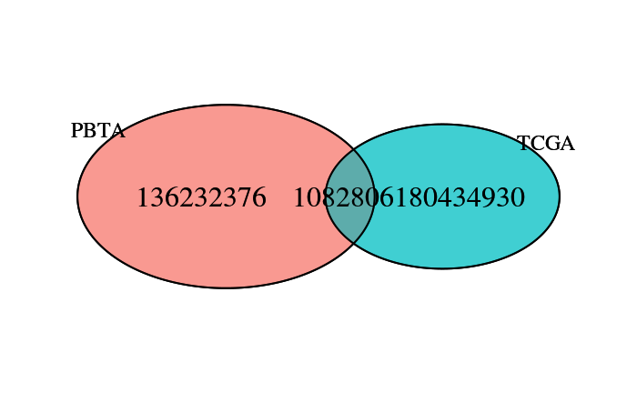

```r
bed_overlap(pbta_granges,
            tcga_granges,
            plot_name = "PBTA vs TCGA WXS target BED",
            name_1 = "PBTA",
            name_2 = "TCGA")
```

Find overlap between the liftover TCGA target BED region and PBTA data.

```
Each of the 2 combined objects has sequence levels not in the other:
  - in 'x': chr7_KI270803v1_alt, chr15_KI270850v1_alt, chr17_KI270909v1_alt, chr19_KI270938v1_alt, chr22_KI270879v1_alt, chrUn_GL000213v1, chrX, chrY
  - in 'y': chrUn
  Make sure to always combine/compare objects based on the same reference
  genome (use suppressWarnings() to suppress this warning).
```

```
 Ratio of PBTA overlapped: 0.487083
 Ratio of TCGA liftover overlapped: 0.7862399
```

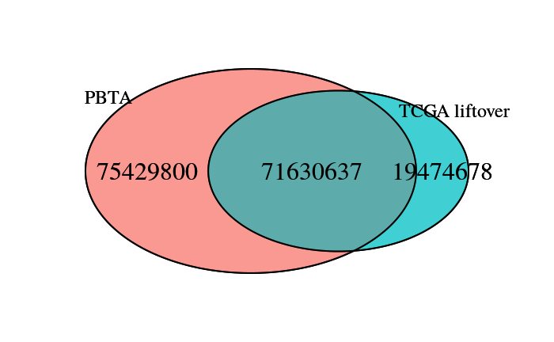

```r
bed_overlap(pbta_granges,
            tcga_lift_granges,
            plot_name = "PBTA vs TCGA WXS liftover target BED",
            name_1 = "PBTA",
            name_2 = "TCGA liftover")
```

```
Each of the 2 combined objects has sequence levels not in the other:
  - in 'x': chr7_KI270803v1_alt, chr15_KI270850v1_alt, chr17_KI270909v1_alt, chr19_KI270938v1_alt, chr22_KI270879v1_alt, chrUn_GL000213v1
  - in 'y': chrUn
  Make sure to always combine/compare objects based on the same reference
  genome (use suppressWarnings() to suppress this warning).
```

```
 Ratio of PBTA CDS overlapped: 0.942882
 Ratio of TCGA lift CDS overlapped: 0.9794732
```

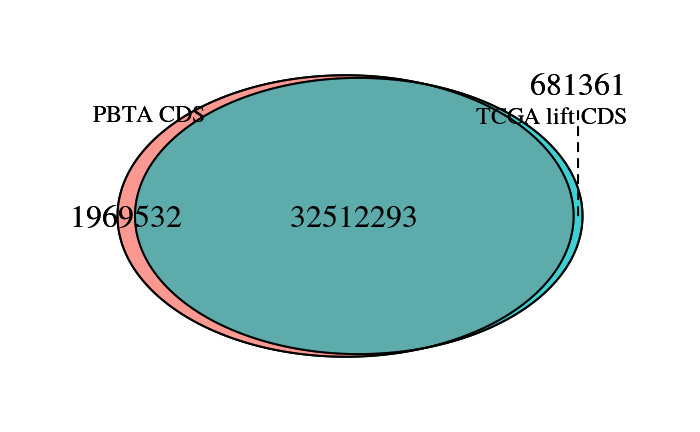

```r
bed_overlap(pbta_cds_granges,
            tcga_lift_cds_granges,
            plot_name = "PBTA vs TCGA WXS liftover coding sequence target BED",
            name_1 = "PBTA CDS",
            name_2 = "TCGA lift CDS")
```

```
 Ratio of PBTA CDS overlapped: 0.08945405
 Ratio of TCGA CDS overlapped: 0.975733
```

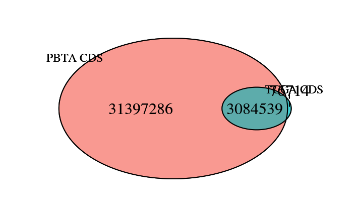

```r
bed_overlap(pbta_cds_granges,
            tcga_cds_granges,
            plot_name = "PBTA vs TCGA WXS Coding sequence target BED",
            name_1 = "PBTA CDS",
            name_2 = "TCGA CDS")
```